# Sampling Swire for Coke Heroes

Jake, Ian, Andrew, Michael

April 05, 2024

# Set up

## Taking a sample of the whole dataset

```r
df <- readRDS("swire_no_nas.rds")  #inject the data and we will sub-sample
```

```r
getwd()
```

```
## [1] "C:/Users/andre/Downloads"
```

```r
regions_joinme <- read.csv("states_summary.csv")

unique(regions_joinme$REGION)
```

```
##  [1] "NORTHERN"    "DESERT_SW"   "PRAIRIE"     "CALI_NEVADA" "MOUNTAIN"
##  [6] "SOCAL"       "ARIZONA"     "NEWMEXICO"   "NOCAL"       "COLORADO"
## [11] "KANSAS"
```

```r
# "NORTHERN"    "DESERT_SW"   "PRAIRIE"     "CALI_NEVADA"  "MOUNTAIN"    "SOCAL"   "ARIZONA"    "NEWMEXICO"   "NOCAL"    "COLORADO"    "KANSAS"

str(regions_joinme)
```

```
## 'data.frame':    200 obs. of  2 variables:
##  $ MARKET_KEY: int  13 70 179 197 272 352 32 33 44 50 ...
##  $ REGION    : chr  "NORTHERN" "NORTHERN" "DESERT_SW" "DESERT_SW" ...
```

```r
# Perform a left join using the merge() function
df <- merge(df, regions_joinme[, c("MARKET_KEY", "REGION")], by = "MARKET_KEY", all.x = TRUE)
rm(regions_joinme)
```

### Quick imputations

```r
# Update CALORIC_SEGMENT values: 0 if 'DIET/LIGHT', otherwise 1
df$CALORIC_SEGMENT <- ifelse(df$CALORIC_SEGMENT == "DIET/LIGHT", 0, 1)
df$MARKET_KEY <- as.character(df$MARKET_KEY)
df <- df %>%
  mutate(
    MONTH = as.numeric(substr(DATE, 6, 7)),  # Extract the month from YYYY-MM-DD format
    SEASON = case_when(
      MONTH %in% c(12, 01, 02) ~ "WINTER",
      MONTH %in% c(03, 04, 05) ~ "SPRING",
      MONTH %in% c(06, 07, 08) ~ "SUMMER",
      MONTH %in% c(09, 10, 11) ~ "FALL",
      TRUE ~ NA_character_  # This is just in case there are any undefined values
    )
  )
```

```r
str(df)
```

```
## 'data.frame':    24461424 obs. of  13 variables:
##  $ MARKET_KEY     : chr  "1" "1" "1" "1" ...
##  $ DATE           : chr  "2021-10-16" "2022-06-04" "2022-02-05" "2022-10-08" ...
##  $ CALORIC_SEGMENT: num  0 0 1 0 0 1 0 0 1 0 ...
##  $ CATEGORY       : chr  "ENERGY" "SSD" "SSD" "SSD" ...
##  $ UNIT_SALES     : num  434 28 42 1 26 161 6 5 68 90 ...
##  $ DOLLAR_SALES   : num  924.04 147.77 25.13 0.99 94.56 ...
##  $ MANUFACTURER   : chr  "PONYS" "SWIRE-CC" "COCOS" "JOLLYS" ...
##  $ BRAND          : chr  "MYTHICAL BEVERAGE ULTRA" "DIET PEPPY CF" "HANSENIZZLE'S ECO" "DIET PAPI" ...
##  $ PACKAGE        : chr  "16SMALL MULTI CUP" "12SMALL 12ONE CUP" "12SMALL 6ONE CUP" "12SMALL 6ONE CUP" ...
##  $ ITEM           : chr  "MYTHICAL BEVERAGE ULTRA SUNRISE ENERGY DRINK UNFLAVORED ZERO SUGAR CUP 16 LIQUID SMALL" "DIET PEPPY CAFFEINE FREE GENTLE DRINK RED  PEPPER COLA DIET CUP 12 LIQUID SMALL X12" "HANSENIZZLE'S ECO GENTLE DRINK MANDARIN DURIAN  CUP 12 LIQUID SMALL" "DIET PAPI GENTLE DRINK COL…
##  $ REGION         : chr  "NORTHERN" "NORTHERN" "NORTHERN" "NORTHERN" ...
##  $ MONTH          : num  10 6 2 10 7 9 9 6 10 5 ...
##  $ SEASON         : chr  "FALL" "SUMMER" "WINTER" "FALL" ...
```

## Making a 10% sample of the data to shrink it

```r
# Assuming df is your dataframe
set.seed(123) # Set a random seed for reproducibility
sampled_df <- df[sample(1:nrow(df), 2446143), ]
rm(df)
```

```r
df <- sampled_df
rm(sampled_df)
```

```r
#skim(df)
```

```r
summary(df)
```

```
##   MARKET_KEY            DATE           CALORIC_SEGMENT    CATEGORY
##  Length:2446143     Length:2446143     Min.   :0.0000   Length:2446143
##  Class :character   Class :character   1st Qu.:0.0000   Class :character
##  Mode  :character   Mode  :character   Median :1.0000   Mode  :character
##                                        Mean   :0.5025
##                                        3rd Qu.:1.0000
##                                        Max.   :1.0000
##    UNIT_SALES        DOLLAR_SALES      MANUFACTURER          BRAND
##  Min.   :    0.04   Min.   :     0.0   Length:2446143     Length:2446143
##  1st Qu.:   11.00   1st Qu.:    36.5   Class :character   Class :character
##  Median :   40.00   Median :   135.1   Mode  :character   Mode  :character
##  Mean   :  173.43   Mean   :   587.4
##  3rd Qu.:  126.00   3rd Qu.:   427.4
##  Max.   :91778.00   Max.   :409159.3
##    PACKAGE              ITEM              REGION              MONTH
##  Length:2446143     Length:2446143     Length:2446143     Min.   : 1.000
##  Class :character   Class :character   Class :character   1st Qu.: 3.000
##  Mode  :character   Mode  :character   Mode  :character   Median : 6.000
##                                                           Mean   : 6.283
##                                                           3rd Qu.: 9.000
##                                                           Max.   :12.000
##     SEASON
##  Length:2446143
##  Class :character
##  Mode  :character
##
##
##
```

### Linear model on sampled data looks the same largely

```r
# Perform a linear regression with UNIT_SALES as the dependent variable
# and PRICE (or your chosen variable) as the independent variable
linear_model <- lm(DOLLAR_SALES ~ UNIT_SALES, data = df)

# Print the summary of the linear model to see the results
summary(linear_model)
```

```
##
## Call:
## lm(formula = DOLLAR_SALES ~ UNIT_SALES, data = df)
##
## Residuals:
##     Min      1Q  Median      3Q     Max
## -140089    -117     -68      -3  225329
##
## Coefficients:
##              Estimate Std. Error t value Pr(>|t|)
## (Intercept) 69.056096   1.023439   67.47   <2e-16 ***
## UNIT_SALES   2.989060   0.001201 2489.17   <2e-16 ***
## ---
## Signif. codes:  0 '***' 0.001 '**' 0.01 '*' 0.05 '.' 0.1 ' ' 1
##
## Residual standard error: 1567 on 2446141 degrees of freedom
## Multiple R-squared:  0.717,  Adjusted R-squared:  0.717
## F-statistic: 6.196e+06 on 1 and 2446141 DF,  p-value: < 2.2e-16
```

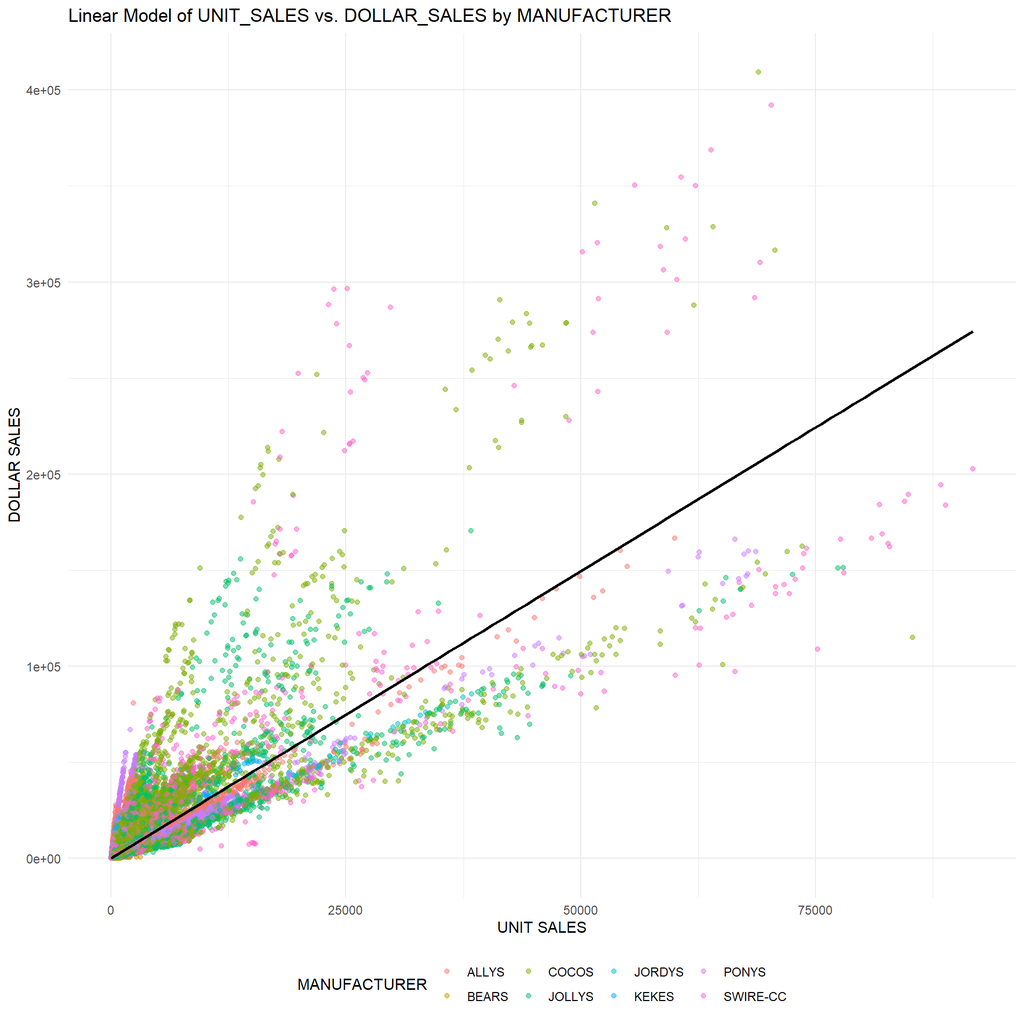

```r
# Create a scatter plot with the regression line, colored by MANUFACTURER
ggplot(df, aes(x = UNIT_SALES, y = DOLLAR_SALES, color = MANUFACTURER)) +
  geom_point(alpha = 0.5) +  # Adjust alpha to avoid overplotting, if necessary
  geom_smooth(method = "lm", color = "black", se = FALSE) +  # Add linear regression line without confidence band for clarity
  labs(title = "Linear Model of UNIT_SALES vs. DOLLAR_SALES by MANUFACTURER",
       x = "UNIT SALES",
       y = "DOLLAR SALES") +
  theme_minimal() +
  theme(legend.position = "bottom")  # Adjust legend position if needed
```

### Models by Total Dollar Sales

#### Mulberries and Diet Square by Total Dollar Sales

> There are only 737 existing observations of the Square brand. Probably not enough to make any strong decisions but we will do some exploration

```r
# Filter the dataframe for only 'SQUARE'
filtered_brand_df <- df %>%
  filter(BRAND == "SQUARE")
```

> This brand seems to only make Sparkling Water and the only Manufacturer is Swuire-CC

```r
filtered_brand_df <- filtered_brand_df %>%
  mutate(
    MONTH = month(ymd(DATE)),  # Extract month using lubridate's ymd function
    MONTH = as.factor(MONTH)   # Convert the extracted month into a factor
  )

str(filtered_brand_df)
```

```
## 'data.frame':    737 obs. of  13 variables:
##  $ MARKET_KEY     : chr  "862" "966" "969" "965" ...
##  $ DATE           : chr  "2023-09-16" "2023-06-10" "2023-05-06" "2023-03-18" ...
##  $ CALORIC_SEGMENT: num  1 1 0 1 1 1 1 0 1 1 ...
##  $ CATEGORY       : chr  "SPARKLING WATER" "SPARKLING WATER" "SPARKLING WATER" "SPARKLING WATER" ...
##  $ UNIT_SALES     : num  2 1 34 6 1 43 2 250 1 5 ...
##  $ DOLLAR_SALES   : num  3.78 1.07 38.72 5.88 1.49 ...
##  $ MANUFACTURER   : chr  "SWIRE-CC" "SWIRE-CC" "SWIRE-CC" "SWIRE-CC" ...
##  $ BRAND          : chr  "SQUARE" "SQUARE" "SQUARE" "SQUARE" ...
##  $ PACKAGE        : chr  "ALL OTHER ONES" "20SMALL MULTI JUG" "20SMALL MULTI JUG" "20SMALL MULTI JUG" ...
##  $ ITEM           : chr  "SQUARE MINERAL WATER SUNSET  JUG 22.29 LIQUID SMALL" "SQUARE MINERAL SPRING WATER DURIAN ADE JUG 20.3 LIQUID SMALL" "SQUARE MINERAL SPRING WATER UNFLAVORED JUG 20.3 LIQUID SMALL" "SQUARE MINERAL SPRING WATER BEVERAGE CASAVA ADE JUG 20.3 LIQUID SMALL" ...
##  $ REGION         : chr  "ARIZONA" "COLORADO" "SOCAL" "COLORADO" ...
##  $ MONTH          : Factor w/ 12 levels "1","2","3","4",..: 9 6 5 3 7 6 11 4 7 4 ...
##  $ SEASON         : chr  "FALL" "SUMMER" "SPRING" "SPRING" ...
```

```r
print(unique(filtered_brand_df$CATEGORY))
```

```
## [1] "SPARKLING WATER"
```

```r
print(unique(filtered_brand_df$MANUFACTURER))
```

```
## [1] "SWIRE-CC"
```

```r
table(filtered_brand_df$REGION)
```

```
##
##     ARIZONA CALI_NEVADA    COLORADO   DESERT_SW      KANSAS    MOUNTAIN
##          20          61         121          33          66          25
##   NEWMEXICO       NOCAL    NORTHERN     PRAIRIE       SOCAL
##          68          95          19          21         208
```

```r
# Assuming 'innovation' is your data frame
model_square <- lm(DOLLAR_SALES ~ UNIT_SALES + CALORIC_SEGMENT + PACKAGE + MONTH  + REGION, data = filtered_brand_df)
summary(model_square)
```

```
##
## Call:
## lm(formula = DOLLAR_SALES ~ UNIT_SALES + CALORIC_SEGMENT + PACKAGE +
##     MONTH + REGION, data = filtered_brand_df)
##
## Residuals:
##     Min      1Q  Median      3Q     Max
## -55.628  -5.502  -0.974   3.420  93.753
##
## Coefficients:
##                         Estimate Std. Error t value Pr(>|t|)
## (Intercept)            -2.906312   6.096024  -0.477 0.633683
## UNIT_SALES              1.044988   0.006187 168.888  < 2e-16 ***
## CALORIC_SEGMENT         4.100692   1.145328   3.580 0.000366 ***
## PACKAGE2L MULTI JUG    16.444104  12.510110   1.314 0.189114
## PACKAGEALL OTHER ONES  -0.074787   3.112663  -0.024 0.980838
## MONTH2                  2.498417   5.030598   0.497 0.619593
## MONTH3                  4.191974   4.772792   0.878 0.380074
## MONTH4                  2.881368   4.683386   0.615 0.538598
## MONTH5                  3.904745   4.703108   0.830 0.406677
## MONTH6                  7.332088   4.667996   1.571 0.116694
## MONTH7                 11.347116   4.657922   2.436 0.015092 *
## MONTH8                  3.411745   9.793741   0.348 0.727673
## MONTH9                 15.527134   4.622923   3.359 0.000825 ***
## MONTH10                12.339058   4.630723   2.665 0.007883 **
## MONTH11                 8.925831   6.129734   1.456 0.145792
## MONTH12                 7.994091   5.708473   1.400 0.161833
## REGIONCALI_NEVADA      -7.387411   4.347459  -1.699 0.089710 .
## REGIONCOLORADO         -7.502755   4.188589  -1.791 0.073681 .
## REGIONDESERT_SW        -2.763729   4.396045  -0.629 0.529757
## REGIONKANSAS          -16.984754   4.434530  -3.830 0.000139 ***
## REGIONMOUNTAIN          0.598028   4.641181   0.129 0.897511
## REGIONNEWMEXICO       -10.544789   4.334738  -2.433 0.015235 *
## REGIONNOCAL            -2.304548   4.199775  -0.549 0.583362
## REGIONNORTHERN         -1.585749   4.195437  -0.378 0.705566
## REGIONPRAIRIE         -10.092927   4.982964  -2.025 0.043190 *
## REGIONSOCAL            -3.935754   4.078192  -0.965 0.334836
## ---
## Signif. codes:  0 '***' 0.001 '**' 0.01 '*' 0.05 '.' 0.1 ' ' 1
##
## Residual standard error: 12.22 on 711 degrees of freedom
## Multiple R-squared:  0.9835, Adjusted R-squared:  0.9829
## F-statistic:  1697 on 25 and 711 DF,  p-value: < 2.2e-16
```

```r
print(unique(filtered_brand_df$PACKAGE))
```

```
## [1] "ALL OTHER ONES"    "20SMALL MULTI JUG" "2L MULTI JUG"
```

```r
table(filtered_brand_df$PACKAGE)
```

```
##
## 20SMALL MULTI JUG      2L MULTI JUG    ALL OTHER ONES
##               696                 1                40
```

> The Northern Region actually doesn’t seem to do too bad here compared to other models involving sparkling water and caloric segment, but there are only 19 observations in the northern region so I don’t think we have a lot to go off here

> September and October do really well here as the fall continues to be the best time of year months/season wise

> From a packaging perspective, I was suprised to see so few options. It seems that historically the Square brand has been packaged using 20SMALL MULTI JUG over 90% of the time.

```r
print(unique(filtered_brand_df$PACKAGE))
```

```
## [1] "ALL OTHER ONES"    "20SMALL MULTI JUG" "2L MULTI JUG"
```

```r
options(scipen = 999)
table(filtered_brand_df$PACKAGE)
```

```
##
## 20SMALL MULTI JUG      2L MULTI JUG    ALL OTHER ONES
##               696                 1                40
```

```r
options(scipen = 999)
```

#### Made a New Smaller “innovation” Data Frame

> To get a bigger data set that matched my innovation product, I decided to look at Sparkling Water. This left me with ~300,000 observations

```r
innovation <- df %>%
  filter(CATEGORY == "SPARKLING WATER")
innovation$CATEGORY <- ifelse(innovation$CATEGORY == "SPARKLING WATER", 0, 1)
print(unique(innovation$CATEGORY))
```

```
## [1] 0
```

```r
innovation <- innovation %>%
  mutate(
    MONTH = month(ymd(DATE)),  # Extract month using lubridate's ymd function
    MONTH = as.factor(MONTH)   # Convert the extracted month into a factor
  )

str(innovation)
```

```
## 'data.frame':    302499 obs. of  13 variables:
##  $ MARKET_KEY     : chr  "743" "13" "260" "686" ...
##  $ DATE           : chr  "2023-05-13" "2021-11-27" "2021-03-06" "2023-09-16" ...
##  $ CALORIC_SEGMENT: num  0 0 0 1 0 0 0 0 0 0 ...
##  $ CATEGORY       : num  0 0 0 0 0 0 0 0 0 0 ...
##  $ UNIT_SALES     : num  23 9 15 1 3 5 4 5 39 165 ...
##  $ DOLLAR_SALES   : num  78.27 31.42 45.22 8.99 10.31 ...
##  $ MANUFACTURER   : chr  "JOLLYS" "BEARS" "BEARS" "SWIRE-CC" ...
##  $ BRAND          : chr  "BUBBLE JOY" "CROWN" "CROWN" "CUPADA ARID" ...
##  $ PACKAGE        : chr  "12SMALL 8ONE CUP" "12SMALL 8ONE CUP" "12SMALL 6ONE CUP" "12SMALL 12ONE CUP" ...
##  $ ITEM           : chr  "BUBBLE JOY SPARKLING WATER KIWANO  BUBBLE JOY NO CALORIES CUP 12 LIQUID SMALL X8" "CROWN SPARKLING WATER UNFLAVORED CALORIE FREE CUP 12 LIQUID SMALL X8" "CROWN SPARKLING WATER DURIAN  ZERO CALORIE CUP 12 LIQUID SMALL X6" "CUPADA ARID GENTLE DRINK GINGER ALE AND RAZZ  SUP…
##  $ REGION         : chr  "ARIZONA" "NORTHERN" "NEWMEXICO" "NOCAL" ...
##  $ MONTH          : Factor w/ 12 levels "1","2","3","4",..: 5 11 3 9 4 5 7 6 12 3 ...
##  $ SEASON         : chr  "SPRING" "FALL" "SPRING" "FALL" ...
```

```r
print(unique(innovation$CATEGORY))
```

```
## [1] 0
```

> The sparkling water is (unsurprisingly) heavily skewed toward being diet or light. I don’t know if we have enough observations of non-diet sparkling water to make any judgements on the impact that has on the dollar or unit sales

```r
table(innovation$CALORIC_SEGMENT)
```

```
##
##      0      1
## 299283   3216
```

#### Innovation Model by Total Dollar Sales

```r
# Assuming 'innovation' is your data frame
model <- lm(DOLLAR_SALES ~ UNIT_SALES + CALORIC_SEGMENT + PACKAGE + MONTH + SEASON + REGION, data = innovation)
summary(model)
```

```
##
## Call:
## lm(formula = DOLLAR_SALES ~ UNIT_SALES + CALORIC_SEGMENT + PACKAGE +
##     MONTH + SEASON + REGION, data = innovation)
##
## Residuals:
##     Min      1Q  Median      3Q     Max
## -5679.6   -16.6     8.2    25.1 23685.1
##
## Coefficients: (3 not defined because of singularities)
##                                  Estimate  Std. Error  t value
## (Intercept)                      3.943702   14.560226    0.271
## UNIT_SALES                       4.023560    0.003943 1020.340
## CALORIC_SEGMENT                -28.358748    3.854965   -7.356
## PACKAGE.5L MULTI JUG             1.675687   14.680980    0.114
## PACKAGE1.5L MULTI JUG          -62.156065   15.353979   -4.048
## PACKAGE11SMALL 6ONE CUP         35.820421   17.823044    2.010
## PACKAGE12SMALL 12ONE CUP        34.003137   14.542806    2.338
## PACKAGE12SMALL 12ONE JUG       419.956737   14.703267   28.562
## PACKAGE12SMALL 15ONE CUP        12.604948   15.909152    0.792
## PACKAGE12SMALL 24ONE CUP       464.233574   15.078913   30.787
## PACKAGE12SMALL 4ONE              6.236485   14.743748    0.423
## PACKAGE12SMALL 6ONE CUP         -8.275638   14.571365   -0.568
## PACKAGE12SMALL 8ONE CUP        -30.348578   14.514691   -2.091
## PACKAGE12SMALL 8ONE JUG          1.028490  198.257381    0.005
## PACKAGE12SMALL MULTI CUP       -34.147901   14.655169   -2.330
## PACKAGE12SMALL MULTI JUG       -95.421882   14.984932   -6.368
## PACKAGE16SMALL MULTI CUP      -112.860136   14.544910   -7.759
## PACKAGE1L MULTI JUG           -118.588218   14.609731   -8.117
## PACKAGE20SMALL 24ONE JUG       179.242905   20.918605    8.569
## PACKAGE20SMALL 6ONE             40.520167   15.335361    2.642
## PACKAGE20SMALL MULTI JUG       -78.967271   14.815394   -5.330
## PACKAGE24 - 25SMALL MULTI JUG -119.088103   15.176051   -7.847
## PACKAGE26-32SMALL MLT          -28.970269   20.569290   -1.408
## PACKAGE2L MULTI JUG            -32.367554   14.969692   -2.162
## PACKAGE6.5SMALL 12ONE           69.693677   89.610772    0.778
## PACKAGE6.5SMALL 20ONE          168.080871   21.979692    7.647
## PACKAGE6.5SMALL MULTI JUG      -49.029056   76.131715   -0.644
## PACKAGE7.5SMALL 10ONE           -1.853995   99.921013   -0.019
## PACKAGEALL OTHER ONES          -16.162511   14.551868   -1.111
```

[output cut: 69 more lines]

```
## REGIONCOLORADO                             0.10065
## REGIONDESERT_SW                            0.04237 *
## REGIONKANSAS                  < 0.0000000000000002 ***
## REGIONMOUNTAIN                             0.67443
## REGIONNEWMEXICO               0.000093433027373104 ***
## REGIONNOCAL                                0.01163 *
## REGIONNORTHERN                0.000000000085248201 ***
## REGIONPRAIRIE                              0.00173 **
## REGIONSOCAL                                0.77671
## ---
## Signif. codes:  0 '***' 0.001 '**' 0.01 '*' 0.05 '.' 0.1 ' ' 1
##
## Residual standard error: 197.7 on 302449 degrees of freedom
## Multiple R-squared:  0.8179, Adjusted R-squared:  0.8178
## F-statistic: 2.772e+04 on 49 and 302449 DF,  p-value: < 0.00000000000000022
```

> Swire plans to release this product for the duration of 1 year but only in the Northern region. What will the forecasted demand be, in weeks, for this product?

> Item Description: Diet Square Mulberries Sparkling Water 10Small MLT

> Caloric Segment: Due to the unbalance of the data, I don’t know how much we should look at this but there does seem to a be negative relationship on dollar sales when the caloric segment is not diet or light

> Brand: Square - We don’t have any information on this brand at this time

> Package Type: 10Small MLT

> Region: Northern is one of the worst performing regions when it comes to Sparkling Water. This is very concerning as this is where they want to release this sparkling water product. New Mexico seems like it would be the best region to release a sparkling water product in.

> Duration: The duration of one year is interesting. It seems that maybe with a smaller timeframe focused on the best months for sparkling water per our data above (either September-November or February-April) might be better.

> Season: Fall seems to be the best month as changing the season to winter, spring, or summer has a negative impact on sales. Summer and winter have a particulary negative relationship with dollar sales wheras as spring has a negative relationship but it is right on the border of being significant.

> Months: As expected based on the seasonal summary above, the fall months had the most positive relationship with dollar sales. Interestingly, the most positive relationship with dollar sales was March, which is likely the driver between Spring being the second best month (April was also a strong month).

#### More Exploration of the Northern Region

> Looking at a subset of the Northern Region only which is where they want to sell this product

```r
northern_region_df <- df %>%
  filter(REGION == 'NORTHERN')

skim(northern_region_df)
```

Data summary

| Name | northern_region_df |
| --- | --- |
| Number of rows | 603390 |
| Number of columns | 13 |
| _______________________ |  |
| Column type frequency: |  |
| character | 9 |
| numeric | 4 |
| ________________________ |  |
| Group variables | None |

**Variable type: character**

| skim_variable | n_missing | complete_rate | min | max | empty | n_unique | whitespace |
| --- | --- | --- | --- | --- | --- | --- | --- |
| MARKET_KEY | 0 | 1 | 1 | 3 | 0 | 52 | 0 |
| DATE | 0 | 1 | 10 | 10 | 0 | 152 | 0 |
| CATEGORY | 0 | 1 | 3 | 18 | 0 | 5 | 0 |
| MANUFACTURER | 0 | 1 | 5 | 8 | 0 | 8 | 0 |
| BRAND | 0 | 1 | 4 | 56 | 0 | 242 | 0 |
| PACKAGE | 0 | 1 | 11 | 26 | 0 | 81 | 0 |
| ITEM | 0 | 1 | 26 | 142 | 0 | 2021 | 0 |
| REGION | 0 | 1 | 8 | 8 | 0 | 1 | 0 |
| SEASON | 0 | 1 | 4 | 6 | 0 | 4 | 0 |

**Variable type: numeric**

| skim_variable | n_missing | complete_rate | mean | sd | p0 | p25 | p50 | p75 | p100 | hist |
| --- | --- | --- | --- | --- | --- | --- | --- | --- | --- | --- |
| CALORIC_SEGMENT | 0 | 1 | 0.49 | 0.50 | 0.00 | 0.00 | 0.00 | 1.00 | 1.00 | ▇▁▁▁▇ |
| UNIT_SALES | 0 | 1 | 151.12 | 339.29 | 0.04 | 13.00 | 49.00 | 143.00 | 9818.00 | ▇▁▁▁▁ |
| DOLLAR_SALES | 0 | 1 | 492.75 | 1113.20 | 0.01 | 45.38 | 162.88 | 467.87 | 40462.59 | ▇▁▁▁▁ |
| MONTH | 0 | 1 | 6.28 | 3.44 | 1.00 | 3.00 | 6.00 | 9.00 | 12.00 | ▇▆▆▅▇ |

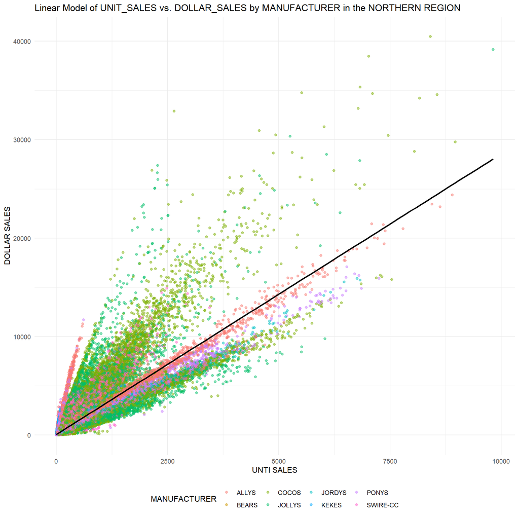

```r
# Create a scatter plot with the regression line, colored by MANUFACTURER
ggplot(northern_region_df, aes(x = UNIT_SALES, y = DOLLAR_SALES, color = MANUFACTURER)) +
  geom_point(alpha = 0.5) +  # Adjust alpha to avoid overplotting, if necessary
  geom_smooth(method = "lm", color = "black", se = FALSE) +  # Add linear regression line without confidence band for clarity
  labs(title = "Linear Model of UNIT_SALES vs. DOLLAR_SALES by MANUFACTURER in the NORTHERN REGION",
       x = "UNTI SALES",
       y = "DOLLAR SALES") +
  theme_minimal() +
  theme(legend.position = "bottom")  # Adjust legend position if needed
```

#### Make the Small Mulberries df

> Now I am going to look at my mulberries subset from the original larger df

```r
mulberries_small <- df[grep("Mulberries", df$ITEM, ignore.case = TRUE), ]
```

```r
skim(mulberries_small)
```

Data summary

| Name | mulberries_small |
| --- | --- |
| Number of rows | 15492 |
| Number of columns | 13 |
| _______________________ |  |
| Column type frequency: |  |
| character | 9 |
| numeric | 4 |
| ________________________ |  |
| Group variables | None |

**Variable type: character**

| skim_variable | n_missing | complete_rate | min | max | empty | n_unique | whitespace |
| --- | --- | --- | --- | --- | --- | --- | --- |
| MARKET_KEY | 0 | 1 | 1 | 4 | 0 | 200 | 0 |
| DATE | 0 | 1 | 10 | 10 | 0 | 152 | 0 |
| CATEGORY | 0 | 1 | 3 | 18 | 0 | 4 | 0 |
| MANUFACTURER | 0 | 1 | 5 | 8 | 0 | 4 | 0 |
| BRAND | 0 | 1 | 5 | 22 | 0 | 10 | 0 |
| PACKAGE | 0 | 1 | 12 | 22 | 0 | 12 | 0 |
| ITEM | 0 | 1 | 61 | 108 | 0 | 21 | 0 |
| REGION | 0 | 1 | 5 | 11 | 0 | 11 | 0 |
| SEASON | 0 | 1 | 4 | 6 | 0 | 4 | 0 |

**Variable type: numeric**

| skim_variable | n_missing | complete_rate | mean | sd | p0 | p25 | p50 | p75 | p100 | hist |
| --- | --- | --- | --- | --- | --- | --- | --- | --- | --- | --- |
| CALORIC_SEGMENT | 0 | 1 | 0.08 | 0.28 | 0.00 | 0.00 | 0.00 | 0.00 | 1.00 | ▇▁▁▁▁ |
| UNIT_SALES | 0 | 1 | 64.85 | 129.10 | 1.00 | 7.00 | 22.00 | 72.00 | 2426.00 | ▇▁▁▁▁ |
| DOLLAR_SALES | 0 | 1 | 202.53 | 463.74 | 0.43 | 17.97 | 53.34 | 168.36 | 9318.13 | ▇▁▁▁▁ |
| MONTH | 0 | 1 | 6.32 | 3.50 | 1.00 | 3.00 | 6.00 | 9.00 | 12.00 | ▇▆▆▃▇ |

```r
model_mulberries <- lm(DOLLAR_SALES ~ UNIT_SALES + CALORIC_SEGMENT + PACKAGE + CATEGORY + SEASON + REGION, data = mulberries_small)
summary(model_mulberries)
```

```
##
## Call:
## lm(formula = DOLLAR_SALES ~ UNIT_SALES + CALORIC_SEGMENT + PACKAGE +
##     CATEGORY + SEASON + REGION, data = mulberries_small)
##
## Residuals:
##      Min       1Q   Median       3Q      Max
## -1789.55   -29.66    -1.00    33.62  1365.87
##
## Coefficients: (1 not defined because of singularities)
##                                 Estimate Std. Error t value
## (Intercept)                     48.40268    3.20339  15.110
## UNIT_SALES                       3.45980    0.00663 521.839
## CALORIC_SEGMENT                 68.13095   94.17300   0.723
## PACKAGE.5L 6ONE JUG            -27.09216    4.11092  -6.590
## PACKAGE12SMALL 12ONE CUP       195.48013   95.83137   2.040
## PACKAGE12SMALL 6ONE CUP        110.73740  191.15427   0.579
## PACKAGE12SMALL 8ONE CUP        -23.55754   94.30714  -0.250
## PACKAGE12SMALL MULTI CUP       -56.90948   95.88481  -0.594
## PACKAGE16SMALL MULTI CUP      -178.99782   94.27776  -1.899
## PACKAGE18SMALL MULTI JUG       -47.16910    4.17394 -11.301
## PACKAGE20SMALL MULTI JUG       -67.81632    5.50084 -12.328
## PACKAGE24 - 25SMALL MULTI JUG  -74.08438    4.08074 -18.155
## PACKAGE2L MULTI JUG             79.04555  186.66856   0.423
## PACKAGEALL OTHER ONES         -101.21518   94.31990  -1.073
## CATEGORYING ENHANCED WATER            NA         NA      NA
## CATEGORYSPARKLING WATER         24.30859   94.24771   0.258
## CATEGORYSSD                   -223.67350   94.19548  -2.375
## SEASONSPRING                     1.00690    2.11897   0.475
## SEASONSUMMER                    -7.00122    2.20879  -3.170
## SEASONWINTER                    -1.86707    2.13356  -0.875
## REGIONCALI_NEVADA              -11.38154    4.45143  -2.557
## REGIONCOLORADO                 -14.95225    2.75001  -5.437
## REGIONDESERT_SW                 -3.91841    3.31499  -1.182
## REGIONKANSAS                   -84.44299    5.38730 -15.674
## REGIONMOUNTAIN                 -19.99081    2.95078  -6.775
## REGIONNEWMEXICO                 -1.07472    4.25430  -0.253
## REGIONNOCAL                     -4.80085    4.46735  -1.075
## REGIONNORTHERN                 -23.42119    2.23721 -10.469
## REGIONPRAIRIE                  -27.69147    4.66951  -5.930
```

[output cut: 23 more lines]

```
## REGIONCOLORADO                     0.0000000549584 ***
## REGIONDESERT_SW                            0.23721
## REGIONKANSAS                  < 0.0000000000000002 ***
## REGIONMOUNTAIN                     0.0000000000129 ***
## REGIONNEWMEXICO                            0.80057
## REGIONNOCAL                                0.28255
## REGIONNORTHERN                < 0.0000000000000002 ***
## REGIONPRAIRIE                      0.0000000030888 ***
## REGIONSOCAL                                0.01134 *
## ---
## Signif. codes:  0 '***' 0.001 '**' 0.01 '*' 0.05 '.' 0.1 ' ' 1
##
## Residual standard error: 92.41 on 15463 degrees of freedom
## Multiple R-squared:  0.9604, Adjusted R-squared:  0.9603
## F-statistic: 1.338e+04 on 28 and 15463 DF,  p-value: < 0.00000000000000022
```

> We have a few potential takeaways from this smaller dataframe focused on the mulberries flavor. We only have ~15,000 observations here but it is worth taking note of.

> Region - similar to the larger model, it appears that the Northern Region is not a great place for this flavor in comparison to some of the other regions. It has a statisticly significant negative relationship in terms of total dollar sales. Unlike the larger Sparkling Water model, it isn’t the worst region, but it still looks as if the Northern Region isn’t big on Sparkling Water

> Season - Spring and Fall again appear to be the best two seasons for sales, thought the difference is not as significant or as extreme for the flavor as it was for Sparkling Water

> Packaging - The larger quantities of small packaging seem to have a significant negative relationship with total dollar sales (PACKAGE18SMALL MULTI JUG, PACKAGE20SMALL MULTI JUG, and PACKAGE24 - 25SMALL MULTI JUG) so going with an option like the one we are exploring 10Small MLT could be a good option.

#### Cleaning

> Cleaning up the item column

```r
mulberries_small <- mulberries_small %>%
  mutate(
    PACKAGE2 = str_extract(ITEM, "(CUP|JUG).*"),  # Extracts the part from CUP or JUG to the end.
    ITEM = str_replace(ITEM, "(CUP|JUG).*", "")  # Replaces the CUP/JUG and everything after it with empty string in ITEM.
  )
```

```r
mulberries_small <- mulberries_small %>%
  mutate(
    TEMP = str_extract(ITEM, "\\d+\\.?\\d*.*"), # Extracts the part from the first number to the end.
    PACKAGE2 = if_else(is.na(PACKAGE2), TEMP, paste(PACKAGE2, TEMP)), # Combines existing PACKAGE2 with new extraction if needed.
    ITEM = str_replace(ITEM, "\\d+\\.?\\d*.*", ""), # Removes the numeric part and everything after it from ITEM.
    TEMP = NULL  # Removes the temporary column.
  )
```

```r
na_rows <- mulberries_small %>%
  filter(is.na(PACKAGE2))
#na_rows
#the above steps excised all packaging out of ITEM column
```

```r
mulberries_small <- mulberries_small %>%
  mutate(
    GENTLE_DRINK = if_else(str_detect(ITEM, "GENTLE DRINK"), 1, 0), # Assigns 1 if "GENTLE DRINK" exists, otherwise 0.
    ITEM = str_replace(ITEM, "GENTLE DRINK", "") # Removes "GENTLE DRINK" from ITEM.
  )
```

```r
mulberries_small <- mulberries_small %>%
  mutate(
    ENERGY_DRINK = if_else(str_detect(ITEM, "ENERGY DRINK"), 1, 0), # Assigns 1 if "ENERGY DRINK" exists, otherwise 0.
    ITEM = str_replace(ITEM, "ENERGY DRINK", "") # Removes "ENERGY DRINK" from ITEM.
  )
```

```r
# Define the pattern as a regular expression
pattern <- "ZERO CALORIES|ZERO CALORIE|ZERO SUGAR|SUGAR FREE|NO CALORIES"

mulberries_small <- mulberries_small %>%
  mutate(
    CALORIC_SEGMENT_TEXT = str_extract(ITEM, pattern), # Extracts matching text based on the pattern.
    ITEM = str_replace_all(ITEM, pattern, "") # Removes extracted text from ITEM.
  )
```

```r
mulberries_small <- mulberries_small %>%
  mutate(
    CALORIC_SEGMENT_TEXT = if_else(str_detect(ITEM, "\\bDIET\\b"),
                                   if_else(is.na(CALORIC_SEGMENT_TEXT), "DIET", paste(CALORIC_SEGMENT_TEXT, "DIET", sep=", ")),
                                   CALORIC_SEGMENT_TEXT)
  )
```

```r
# Function to remove the second instance of any repeating word
remove_second_instance <- function(item) {
  words <- unlist(str_split(item, "\\s+")) # Split item into words
  unique_words <- unique(words) # Get unique words to check for repeats
  for (word in unique_words) {
    word_indices <- which(words == word) # Find all indices of the current word
    if (length(word_indices) > 1) { # If there is more than one occurrence
      words[word_indices[2]] <- "" # Remove the second occurrence
    }
  }
  return(paste(words, collapse = " ")) # Reconstruct sentence without the second instance
}

# Apply the function to the 'ITEM' column
mulberries_small <- mulberries_small %>%
  mutate(ITEM = sapply(ITEM, remove_second_instance))


# Remove specific columns
mulberries_small <- select(mulberries_small, -PACKAGE2, -GENTLE_DRINK, -ENERGY_DRINK, -CALORIC_SEGMENT_TEXT)
```

```r
head(mulberries_small)
```

```
##          MARKET_KEY       DATE CALORIC_SEGMENT        CATEGORY UNIT_SALES
## 21727742        965 2021-07-10               0 SPARKLING WATER         49
## 5922403         244 2022-08-06               0 SPARKLING WATER         37
## 5272324         212 2021-05-29               0 SPARKLING WATER          1
## 13595349        620 2023-09-23               0 SPARKLING WATER          8
## 17660989        806 2020-12-26               0 SPARKLING WATER         12
## 21102597        951 2023-03-25               0 SPARKLING WATER          5
##          DOLLAR_SALES MANUFACTURER            BRAND           PACKAGE
## 21727742        72.74       JOLLYS       BUBBLE JOY 16SMALL MULTI CUP
## 5922403        147.82        COCOS EXCLAMATION SODA  12SMALL 8ONE CUP
## 5272324          3.98        BEARS            CROWN  12SMALL 8ONE CUP
## 13595349        33.44        COCOS EXCLAMATION SODA  12SMALL 8ONE CUP
## 17660989        69.58       JOLLYS       BUBBLE JOY    ALL OTHER ONES
## 21102597         9.55       JOLLYS       BUBBLE JOY 16SMALL MULTI CUP
##                                                                        ITEM
## 21727742                           BUBBLE JOY SPARKLING WATER MULBERRIES
## 5922403  EXCLAMATION REFRESHER SPARKLING WATER MULBERRIES PLUS SUPER-JUICE
## 5272324                   CROWN CURATE SPARKLING WATER MULBERRIES CUCUMBER
## 13595349 EXCLAMATION REFRESHER SPARKLING WATER MULBERRIES PLUS SUPER-JUICE
## 17660989                             BUBBLE JOY SPARKLING WATER MULBERRIES
## 21102597                           BUBBLE JOY SPARKLING WATER MULBERRIES
##               REGION MONTH SEASON
## 21727742    COLORADO     7 SUMMER
## 5922403  CALI_NEVADA     8 SUMMER
## 5272324    DESERT_SW     5 SPRING
## 13595349    MOUNTAIN     9   FALL
## 17660989       SOCAL    12 WINTER
## 21102597     ARIZONA     3 SPRING
```

> Mulberris Small is now cleaned up and ready for analysis

#### Region and Category Subset by Total Dollar Sales

> Looking at a subset of the Northern Region and Sparkling Water. This returns ~80,000 observations

```r
northern_sparkling_df <- df %>%
  filter(REGION == 'NORTHERN') %>%
  filter(CATEGORY == 'SPARKLING WATER')

skim(northern_sparkling_df)
```

Data summary

| Name | northern_sparkling_df |
| --- | --- |
| Number of rows | 79523 |
| Number of columns | 13 |
| _______________________ |  |
| Column type frequency: |  |
| character | 9 |
| numeric | 4 |
| ________________________ |  |
| Group variables | None |

**Variable type: character**

| skim_variable | n_missing | complete_rate | min | max | empty | n_unique | whitespace |
| --- | --- | --- | --- | --- | --- | --- | --- |
| MARKET_KEY | 0 | 1 | 1 | 3 | 0 | 52 | 0 |
| DATE | 0 | 1 | 10 | 10 | 0 | 148 | 0 |
| CATEGORY | 0 | 1 | 15 | 15 | 0 | 1 | 0 |
| MANUFACTURER | 0 | 1 | 5 | 8 | 0 | 4 | 0 |
| BRAND | 0 | 1 | 5 | 35 | 0 | 19 | 0 |
| PACKAGE | 0 | 1 | 12 | 22 | 0 | 23 | 0 |
| ITEM | 0 | 1 | 48 | 142 | 0 | 282 | 0 |
| REGION | 0 | 1 | 8 | 8 | 0 | 1 | 0 |
| SEASON | 0 | 1 | 4 | 6 | 0 | 4 | 0 |

**Variable type: numeric**

| skim_variable | n_missing | complete_rate | mean | sd | p0 | p25 | p50 | p75 | p100 | hist |
| --- | --- | --- | --- | --- | --- | --- | --- | --- | --- | --- |
| CALORIC_SEGMENT | 0 | 1 | 0.01 | 0.11 | 0.0 | 0 | 0.00 | 0.00 | 1.00 | ▇▁▁▁▁ |
| UNIT_SALES | 0 | 1 | 64.75 | 89.71 | 1.0 | 8 | 33.00 | 85.00 | 1752.00 | ▇▁▁▁▁ |
| DOLLAR_SALES | 0 | 1 | 236.42 | 352.95 | 0.3 | 24 | 106.87 | 304.38 | 6119.75 | ▇▁▁▁▁ |
| MONTH | 0 | 1 | 6.23 | 3.43 | 1.0 | 3 | 6.00 | 9.00 | 12.00 | ▇▆▆▅▇ |

```r
str(northern_sparkling_df)
```

```
## 'data.frame':    79523 obs. of  13 variables:
##  $ MARKET_KEY     : chr  "13" "144" "452" "405" ...
##  $ DATE           : chr  "2021-11-27" "2023-09-02" "2021-12-18" "2021-10-30" ...
##  $ CALORIC_SEGMENT: num  0 0 0 0 0 0 0 0 0 0 ...
##  $ CATEGORY       : chr  "SPARKLING WATER" "SPARKLING WATER" "SPARKLING WATER" "SPARKLING WATER" ...
##  $ UNIT_SALES     : num  9 82 18 35 4 12 2 49 12 21 ...
##  $ DOLLAR_SALES   : num  31.42 333.22 26.82 55.03 9.96 ...
##  $ MANUFACTURER   : chr  "BEARS" "JOLLYS" "BEARS" "JOLLYS" ...
##  $ BRAND          : chr  "CROWN" "BUBBLE JOY" "CROWN" "BUBBLE JOY" ...
##  $ PACKAGE        : chr  "12SMALL 8ONE CUP" "12SMALL 8ONE CUP" "26-32SMALL MLT" "16SMALL MULTI CUP" ...
##  $ ITEM           : chr  "CROWN SPARKLING WATER UNFLAVORED CALORIE FREE CUP 12 LIQUID SMALL X8" "BUBBLE JOY SPARKLING WATER YELLOW  BUBBLE JOY NO CALORIES CUP 12 LIQUID SMALL X8" "CROWN SPARKLING WATER SUNSET  CALORIE FREE JUG 32 LIQUID SMALL" "BUBBLE JOY SPARKLING WATER PINK  BUBBLE JOY NO CALOR…
##  $ REGION         : chr  "NORTHERN" "NORTHERN" "NORTHERN" "NORTHERN" ...
##  $ MONTH          : num  11 9 12 10 1 1 6 4 12 7 ...
##  $ SEASON         : chr  "FALL" "FALL" "WINTER" "FALL" ...
```

```r
model_north_sparkling <- lm(DOLLAR_SALES ~ UNIT_SALES + PACKAGE + SEASON , data = northern_sparkling_df)
summary(model_north_sparkling)
```

```
##
## Call:
## lm(formula = DOLLAR_SALES ~ UNIT_SALES + PACKAGE + SEASON, data = northern_sparkling_df)
##
## Residuals:
##      Min       1Q   Median       3Q      Max
## -1768.23   -18.82    -1.51    22.18  2693.60
##
## Coefficients:
##                                  Estimate  Std. Error t value
## (Intercept)                     12.952050   20.616252   0.628
## UNIT_SALES                       3.688909    0.003933 938.035
## PACKAGE.5L MULTI JUG            -1.492129   20.691653  -0.072
## PACKAGE1.5L MULTI JUG          -28.901418   21.329404  -1.355
## PACKAGE11SMALL 6ONE CUP          1.740066   21.507766   0.081
## PACKAGE12SMALL 12ONE CUP        49.715082   20.640108   2.409
## PACKAGE12SMALL 12ONE JUG       341.048087   20.727496  16.454
## PACKAGE12SMALL 15ONE CUP        12.497362   21.144544   0.591
## PACKAGE12SMALL 24ONE CUP        88.480177   23.610847   3.747
## PACKAGE12SMALL 4ONE             24.896288   20.770203   1.199
## PACKAGE12SMALL 6ONE CUP         -8.713635   20.652635  -0.422
## PACKAGE12SMALL 8ONE CUP          1.263834   20.624606   0.061
## PACKAGE12SMALL 8ONE JUG         -4.492604   92.188289  -0.049
## PACKAGE12SMALL MULTI CUP       -32.983697   20.688240  -1.594
## PACKAGE12SMALL MULTI JUG       -87.589570   21.129408  -4.145
## PACKAGE16SMALL MULTI CUP      -117.512503   20.640731  -5.693
## PACKAGE1L MULTI JUG           -102.723202   20.659191  -4.972
## PACKAGE20SMALL 6ONE             23.165848   21.250222   1.090
## PACKAGE20SMALL MULTI JUG       -21.861268   21.013913  -1.040
## PACKAGE24 - 25SMALL MULTI JUG -125.811111   20.990754  -5.994
## PACKAGE26-32SMALL MLT          -32.935282   21.665415  -1.520
## PACKAGE2L MULTI JUG            -19.217937   21.141338  -0.909
## PACKAGE7.5SMALL 10ONE           -5.803100   55.823004  -0.104
## PACKAGEALL OTHER ONES          -32.428390   20.646772  -1.571
## SEASONSPRING                    -4.912611    0.908825  -5.405
## SEASONSUMMER                    -8.918355    0.942540  -9.462
## SEASONWINTER                    -8.391330    0.918996  -9.131
##                                           Pr(>|t|)
## (Intercept)                               0.529845
## UNIT_SALES                    < 0.0000000000000002 ***
```

[output cut: 16 more lines]

```
## PACKAGE20SMALL MULTI JUG                  0.298193
## PACKAGE24 - 25SMALL MULTI JUG        0.00000000206 ***
## PACKAGE26-32SMALL MLT                     0.128470
## PACKAGE2L MULTI JUG                       0.363341
## PACKAGE7.5SMALL 10ONE                     0.917205
## PACKAGEALL OTHER ONES                     0.116273
## SEASONSPRING                         0.00000006483 ***
## SEASONSUMMER                  < 0.0000000000000002 ***
## SEASONWINTER                  < 0.0000000000000002 ***
## ---
## Signif. codes:  0 '***' 0.001 '**' 0.01 '*' 0.05 '.' 0.1 ' ' 1
##
## Residual standard error: 89.85 on 79496 degrees of freedom
## Multiple R-squared:  0.9352, Adjusted R-squared:  0.9352
## F-statistic: 4.414e+04 on 26 and 79496 DF,  p-value: < 0.00000000000000022
```

#### Mulberries and Diet Square Final Thoughts

> Some interesting takeaways here:

> Packaging: Continues the trend of getting more negative and more statistically significant in the large values

#### Product 4 Summary Total Dollar Sales

> I do not think that we should recommend this product. We have very few observations of our Square Brand, and only 19 of those reside in the Northern Region. When widening the scope to look at other factors such as the flavor, category, and region as a whole, it continues to not make sense to sell this product for a whole year in the Northern Region.

> The Northern Region consistantly demonstrated a negative relationship with total dollar sales in comparison with the other regions we reviewed. The Square brand has been primarily sold in California and the Southwest so far and we don’t have sufficient data to say that this brand would do better than the other sparkling waters that have not done well in the Northern Region

> From a flavor and category perspective, we were able to gain more insights such as the best type of packaging associated with the flavor, but the northern region continued to perform poorly with the flavor mulberries

> In summary, I would not recommend we move forward with this product due to the small amount of historical data that we have with the brand and flavor and the poor performance of the region.

### Models by Unit Sales

#### Sparkling Water Model by Unit Sales

```r
model_inn_us <- lm(UNIT_SALES ~ DOLLAR_SALES + CALORIC_SEGMENT + PACKAGE + MONTH + SEASON + REGION, data = innovation)
summary(model_inn_us)
```

```
##
## Call:
## lm(formula = UNIT_SALES ~ DOLLAR_SALES + CALORIC_SEGMENT + PACKAGE +
##     MONTH + SEASON + REGION, data = innovation)
##
## Residuals:
##     Min      1Q  Median      3Q     Max
## -3947.1   -14.5    -3.6     5.7  1511.4
##
## Coefficients: (3 not defined because of singularities)
##                                  Estimate  Std. Error  t value
## (Intercept)                   -21.5764074   3.1852531   -6.774
## DOLLAR_SALES                    0.1925874   0.0001887 1020.340
## CALORIC_SEGMENT                 3.8457490   0.8434379    4.560
## PACKAGE.5L MULTI JUG           15.9825346   3.2117814    4.976
## PACKAGE1.5L MULTI JUG          34.1300983   3.3586696   10.162
## PACKAGE11SMALL 6ONE CUP        10.7735194   3.8993122    2.763
## PACKAGE12SMALL 12ONE CUP       17.0219132   3.1815612    5.350
## PACKAGE12SMALL 12ONE JUG      -50.7920555   3.2198000  -15.775
## PACKAGE12SMALL 15ONE CUP        8.3627190   3.4805834    2.403
## PACKAGE12SMALL 24ONE CUP      -49.2844666   3.3029226  -14.921
## PACKAGE12SMALL 4ONE            20.3164928   3.2254346    6.299
## PACKAGE12SMALL 6ONE CUP        18.6422471   3.1877527    5.848
## PACKAGE12SMALL 8ONE CUP        40.1704465   3.1747149   12.653
## PACKAGE12SMALL 8ONE JUG        12.0779778  43.3748529    0.278
## PACKAGE12SMALL MULTI CUP       21.9675666   3.2060459    6.852
## PACKAGE12SMALL MULTI JUG       43.7707191   3.2776652   13.354
## PACKAGE16SMALL MULTI CUP       47.8545915   3.1812703   15.043
## PACKAGE1L MULTI JUG            48.6168830   3.1954505   15.214
## PACKAGE20SMALL 24ONE JUG      -14.5357180   4.5770631   -3.176
## PACKAGE20SMALL 6ONE            12.7734269   3.3550369    3.807
## PACKAGE20SMALL MULTI JUG       38.5635911   3.2407137   11.900
## PACKAGE24 - 25SMALL MULTI JUG  53.0195344   3.3191628   15.974
## PACKAGE26-32SMALL MLT          21.3081012   4.5000085    4.735
## PACKAGE2L MULTI JUG            27.9381714   3.2747088    8.531
## PACKAGE6.5SMALL 12ONE         -36.3620167  19.6050019   -1.855
## PACKAGE6.5SMALL 20ONE         -18.6950731   4.8090738   -3.887
## PACKAGE6.5SMALL MULTI JUG     -16.0610249  16.6561242   -0.964
## PACKAGE7.5SMALL 10ONE          15.4460671  21.8607560    0.707
## PACKAGEALL OTHER ONES          24.7833831   3.1833531    7.785
```

[output cut: 69 more lines]

```
## REGIONCOLORADO                < 0.0000000000000002 ***
## REGIONDESERT_SW                0.00000000042730184 ***
## REGIONKANSAS                  < 0.0000000000000002 ***
## REGIONMOUNTAIN                < 0.0000000000000002 ***
## REGIONNEWMEXICO                           0.001149 **
## REGIONNOCAL                    0.00000000019828111 ***
## REGIONNORTHERN                < 0.0000000000000002 ***
## REGIONPRAIRIE                  0.00000001736015851 ***
## REGIONSOCAL                               0.044039 *
## ---
## Signif. codes:  0 '***' 0.001 '**' 0.01 '*' 0.05 '.' 0.1 ' ' 1
##
## Residual standard error: 43.26 on 302449 degrees of freedom
## Multiple R-squared:  0.8174, Adjusted R-squared:  0.8174
## F-statistic: 2.763e+04 on 49 and 302449 DF,  p-value: < 0.00000000000000022
```

> Kansas is an extreme outlier here in terms of unit sales with an extremely high positive change in UNIT_SALES when selling in Kansas.

> The best months are in the summer for unit sales even though the fall was the clear leader for total dollar sales

#### Mulberries by Unit Sales

```r
model_mulberries_us <- lm(UNIT_SALES ~ DOLLAR_SALES + CALORIC_SEGMENT + CATEGORY + PACKAGE + MONTH + SEASON + REGION, data = mulberries_small)
summary(model_mulberries_us)
```

```
##
## Call:
## lm(formula = UNIT_SALES ~ DOLLAR_SALES + CALORIC_SEGMENT + CATEGORY +
##     PACKAGE + MONTH + SEASON + REGION, data = mulberries_small)
##
## Residuals:
##     Min      1Q  Median      3Q     Max
## -290.10   -9.19   -0.66    6.75  523.72
##
## Coefficients: (1 not defined because of singularities)
##                                  Estimate  Std. Error t value
## (Intercept)                    19.6169949  26.5280456   0.739
## DOLLAR_SALES                    0.2734725   0.0005238 522.065
## CALORIC_SEGMENT               -29.2103985  26.4668558  -1.104
## CATEGORYING ENHANCED WATER    -37.9540157  26.5079911  -1.432
## CATEGORYSPARKLING WATER       -15.7917089  26.4885823  -0.596
## CATEGORYSSD                    53.5244990  26.4712274   2.022
## PACKAGE.5L 6ONE JUG             7.5874869   1.1553139   6.567
## PACKAGE12SMALL 12ONE CUP      -85.1713851   5.2214259 -16.312
## PACKAGE12SMALL 6ONE CUP       -50.3389519  28.8999134  -1.742
## PACKAGE12SMALL 8ONE CUP       -15.9592977   0.8127858 -19.635
## PACKAGE12SMALL MULTI CUP      -14.7972997   4.9630854  -2.981
## PACKAGE16SMALL MULTI CUP       23.5878243   0.8476019  27.829
## PACKAGE18SMALL MULTI JUG       12.7261753   1.1731954  10.847
## PACKAGE20SMALL MULTI JUG       17.7690053   1.5467624  11.488
## PACKAGE24 - 25SMALL MULTI JUG  20.5970313   1.1469166  17.959
## PACKAGE2L MULTI JUG           -41.1844548  26.4821419  -1.555
## PACKAGEALL OTHER ONES                  NA          NA      NA
## MONTH                           0.3490849   0.0770380   4.531
## SEASONSPRING                    2.0396573   0.7494619   2.721
## SEASONSUMMER                    3.5094480   0.6635267   5.289
## SEASONWINTER                    2.5801403   0.7044123   3.663
## REGIONCALI_NEVADA               4.0926749   1.2507349   3.272
## REGIONCOLORADO                  6.6978722   0.7715703   8.681
## REGIONDESERT_SW                 1.0620570   0.9314629   1.140
## REGIONKANSAS                   37.8097003   1.4951713  25.288
## REGIONMOUNTAIN                  6.7526902   0.8285780   8.150
## REGIONNEWMEXICO                 0.7319623   1.1954410   0.612
## REGIONNOCAL                     0.6164916   1.2553365   0.491
## REGIONNORTHERN                  9.2415013   0.6264570  14.752
```

[output cut: 25 more lines]

```
## REGIONCOLORADO                < 0.0000000000000002 ***
## REGIONDESERT_SW                            0.25422
## REGIONKANSAS                  < 0.0000000000000002 ***
## REGIONMOUNTAIN                0.000000000000000392 ***
## REGIONNEWMEXICO                            0.54035
## REGIONNOCAL                                0.62337
## REGIONNORTHERN                < 0.0000000000000002 ***
## REGIONPRAIRIE                 0.000000000002218542 ***
## REGIONSOCAL                                0.03873 *
## ---
## Signif. codes:  0 '***' 0.001 '**' 0.01 '*' 0.05 '.' 0.1 ' ' 1
##
## Residual standard error: 25.96 on 15462 degrees of freedom
## Multiple R-squared:  0.9596, Adjusted R-squared:  0.9596
## F-statistic: 1.267e+04 on 29 and 15462 DF,  p-value: < 0.00000000000000022
```

#### Square Brand Model by Unit Sales

```r
model_square_us <- lm(UNIT_SALES ~ DOLLAR_SALES + CALORIC_SEGMENT + PACKAGE  + MONTH + SEASON + REGION, data = filtered_brand_df)
summary(model_square_us)
```

```
##
## Call:
## lm(formula = UNIT_SALES ~ DOLLAR_SALES + CALORIC_SEGMENT + PACKAGE +
##     MONTH + SEASON + REGION, data = filtered_brand_df)
##
## Residuals:
##     Min      1Q  Median      3Q     Max
## -82.447  -3.914   0.478   4.939  64.000
##
## Coefficients: (3 not defined because of singularities)
##                         Estimate Std. Error t value             Pr(>|t|)
## (Intercept)             3.873513   5.761299   0.672             0.501590
## DOLLAR_SALES            0.933675   0.005528 168.888 < 0.0000000000000002 ***
## CALORIC_SEGMENT        -3.488698   1.084463  -3.217             0.001354 **
## PACKAGE2L MULTI JUG   -19.927878  11.815812  -1.687             0.092130 .
## PACKAGEALL OTHER ONES  -0.936736   2.942007  -0.318             0.750275
## MONTH2                 -2.201041   4.755234  -0.463             0.643601
## MONTH3                 -4.042867   4.511336  -0.896             0.370472
## MONTH4                 -3.231400   4.426446  -0.730             0.465618
## MONTH5                 -4.194368   4.444940  -0.944             0.345681
## MONTH6                 -6.993923   4.412238  -1.585             0.113384
## MONTH7                -10.684455   4.402998  -2.427             0.015487 *
## MONTH8                 -2.035964   9.257917  -0.220             0.826000
## MONTH9                -14.631274   4.369989  -3.348             0.000856 ***
## MONTH10               -11.672601   4.377113  -2.667             0.007833 **
## MONTH11                -9.270671   5.792281  -1.601             0.109927
## MONTH12                -9.220038   5.392242  -1.710             0.087726 .
## SEASONSPRING                  NA         NA      NA                   NA
## SEASONSUMMER                  NA         NA      NA                   NA
## SEASONWINTER                  NA         NA      NA                   NA
## REGIONCALI_NEVADA       6.265228   4.111021   1.524             0.127951
## REGIONCOLORADO          6.549593   3.960539   1.654             0.098627 .
## REGIONDESERT_SW         1.878667   4.155878   0.452             0.651370
## REGIONKANSAS           19.425953   4.171582   4.657           0.00000383 ***
## REGIONMOUNTAIN         -0.955962   4.386937  -0.218             0.827561
## REGIONNEWMEXICO         9.822589   4.097862   2.397             0.016787 *
## REGIONNOCAL             2.243117   3.969747   0.565             0.572216
## REGIONNORTHERN          0.932818   3.965941   0.235             0.814116
## REGIONPRAIRIE           9.040913   4.711485   1.919             0.055396 .
## REGIONSOCAL             4.882067   3.853049   1.267             0.205547
## ---
## Signif. codes:  0 '***' 0.001 '**' 0.01 '*' 0.05 '.' 0.1 ' ' 1
##
## Residual standard error: 11.55 on 711 degrees of freedom
## Multiple R-squared:  0.9839, Adjusted R-squared:  0.9833
## F-statistic:  1737 on 25 and 711 DF,  p-value: < 0.00000000000000022
```

#### Sparkling Water in Northern Region Model by Unit Sales

```r
model_north_sparkling_us <- lm(UNIT_SALES ~ DOLLAR_SALES + PACKAGE + MONTH   + SEASON , data = northern_sparkling_df)
summary(model_north_sparkling_us)
```

```
##
## Call:
## lm(formula = UNIT_SALES ~ DOLLAR_SALES + PACKAGE + MONTH + SEASON,
##     data = northern_sparkling_df)
##
## Residuals:
##     Min      1Q  Median      3Q     Max
## -640.20   -6.98   -1.93    4.55  499.78
##
## Coefficients:
##                                 Estimate Std. Error t value
## (Intercept)                    -4.288677   5.360901  -0.800
## DOLLAR_SALES                    0.248622   0.000265 938.118
## PACKAGE.5L MULTI JUG            0.415718   5.371288   0.077
## PACKAGE1.5L MULTI JUG           7.873423   5.536837   1.422
## PACKAGE11SMALL 6ONE CUP        -0.527659   5.583150  -0.095
## PACKAGE12SMALL 12ONE CUP       -8.379830   5.358021  -1.564
## PACKAGE12SMALL 12ONE JUG      -81.394736   5.382010 -15.123
## PACKAGE12SMALL 15ONE CUP       -2.222811   5.488876  -0.405
## PACKAGE12SMALL 24ONE CUP      -20.603381   6.129179  -3.362
## PACKAGE12SMALL 4ONE            -4.490303   5.391704  -0.833
## PACKAGE12SMALL 6ONE CUP         2.199394   5.361161   0.410
## PACKAGE12SMALL 8ONE CUP         7.855857   5.353811   1.467
## PACKAGE12SMALL 8ONE JUG        -0.038663  23.930916  -0.002
## PACKAGE12SMALL MULTI CUP        8.589750   5.370403   1.599
## PACKAGE12SMALL MULTI JUG       24.355058   5.484836   4.440
## PACKAGE16SMALL MULTI CUP       33.085128   5.357877   6.175
## PACKAGE1L MULTI JUG            29.014663   5.362708   5.410
## PACKAGE20SMALL 6ONE            -5.221944   5.516295  -0.947
## PACKAGE20SMALL MULTI JUG        5.842093   5.454944   1.071
## PACKAGE24 - 25SMALL MULTI JUG  37.519763   5.448539   6.886
## PACKAGE26-32SMALL MLT           8.711516   5.624061   1.549
## PACKAGE2L MULTI JUG             4.954853   5.488024   0.903
## PACKAGE7.5SMALL 10ONE           1.012681  14.490941   0.070
## PACKAGEALL OTHER ONES           9.497577   5.359617   1.772
## MONTH                           0.119909   0.031522   3.804
## SEASONSPRING                    1.960452   0.299350   6.549
## SEASONSUMMER                    3.804840   0.262089  14.517
## SEASONWINTER                    2.628556   0.285872   9.195
##                                           Pr(>|t|)
```

[output cut: 19 more lines]

```
## PACKAGE24 - 25SMALL MULTI JUG     0.00000000000577 ***
## PACKAGE26-32SMALL MLT                     0.121392
## PACKAGE2L MULTI JUG                       0.366609
## PACKAGE7.5SMALL 10ONE                     0.944286
## PACKAGEALL OTHER ONES                     0.076388 .
## MONTH                                     0.000143 ***
## SEASONSPRING                      0.00000000005826 ***
## SEASONSUMMER                  < 0.0000000000000002 ***
## SEASONWINTER                  < 0.0000000000000002 ***
## ---
## Signif. codes:  0 '***' 0.001 '**' 0.01 '*' 0.05 '.' 0.1 ' ' 1
##
## Residual standard error: 23.32 on 79495 degrees of freedom
## Multiple R-squared:  0.9324, Adjusted R-squared:  0.9324
## F-statistic: 4.062e+04 on 27 and 79495 DF,  p-value: < 0.00000000000000022
```

> Kansas is an extreme outlier here in terms of unit sales with an extremely high positive change in UNIT_SALES when selling in Kansas.

> The best months are in the summer for unit sales even though the fall was the clear leader for total dollar sales

> The packaging is also better for the larger numbers wheras with total dollar sales it was the other way around

```r
library(xgboost)
library(caret)
library(dplyr)
```

```r
str(mulberries_small)
```

```
## 'data.frame':    15492 obs. of  13 variables:
##  $ MARKET_KEY     : chr  "965" "244" "212" "620" ...
##  $ DATE           : chr  "2021-07-10" "2022-08-06" "2021-05-29" "2023-09-23" ...
##  $ CALORIC_SEGMENT: num  0 0 0 0 0 0 0 0 0 0 ...
##  $ CATEGORY       : chr  "SPARKLING WATER" "SPARKLING WATER" "SPARKLING WATER" "SPARKLING WATER" ...
##  $ UNIT_SALES     : num  49 37 1 8 12 5 8 5 535 2 ...
##  $ DOLLAR_SALES   : num  72.74 147.82 3.98 33.44 69.58 ...
##  $ MANUFACTURER   : chr  "JOLLYS" "COCOS" "BEARS" "COCOS" ...
##  $ BRAND          : chr  "BUBBLE JOY" "EXCLAMATION SODA" "CROWN" "EXCLAMATION SODA" ...
##  $ PACKAGE        : chr  "16SMALL MULTI CUP" "12SMALL 8ONE CUP" "12SMALL 8ONE CUP" "12SMALL 8ONE CUP" ...
##  $ ITEM           : Named chr  "BUBBLE JOY SPARKLING WATER MULBERRIES   " "EXCLAMATION REFRESHER SPARKLING WATER MULBERRIES PLUS SUPER-JUICE " "CROWN CURATE SPARKLING WATER MULBERRIES CUCUMBER " "EXCLAMATION REFRESHER SPARKLING WATER MULBERRIES PLUS SUPER-JUICE " ...
##   ..- attr(*, "names")= chr [1:15492] "BUBBLE JOY SPARKLING WATER MULBERRIES  BUBBLE JOY  " "EXCLAMATION REFRESHER  SPARKLING WATER MULBERRIES  PLUS SUPER-JUICE  " "CROWN CURATE SPARKLING WATER MULBERRIES  CUCUMBER " "EXCLAMATION REFRESHER  SPARKLING WATER MULBERRIES  PLUS SUPER-JUICE  " ...
##  $ REGION         : chr  "COLORADO" "CALI_NEVADA" "DESERT_SW" "MOUNTAIN" ...
##  $ MONTH          : num  7 8 5 9 12 3 12 9 7 1 ...
##  $ SEASON         : chr  "SUMMER" "SUMMER" "SPRING" "FALL" ...
```

```r
library(caret)

# Assuming you have already loaded your data into mulberries_small dataframe

# Remove the MARKET_KEY column
mulberries_small <- mulberries_small[, !names(mulberries_small) %in% "MARKET_KEY"]

# Identify categorical variables
categorical_cols <- c("CATEGORY", "MANUFACTURER", "BRAND", "PACKAGE", "REGION", "SEASON")

# One-hot encode categorical variables
encoded_data <- dummyVars("~.", data = mulberries_small[categorical_cols], fullRank = TRUE)
encoded_data <- predict(encoded_data, newdata = mulberries_small[categorical_cols])

# Bind the encoded variables with the original dataframe
mulberries_encoded <- cbind(mulberries_small, encoded_data)

# Remove the original categorical variables
mulberries_encoded <- mulberries_encoded[, !(names(mulberries_encoded) %in% categorical_cols)]

# Now you can proceed with the modeling process
```

```r
str(mulberries_encoded)
```

```
## 'data.frame':    15492 obs. of  45 variables:
##  $ DATE                         : chr  "2021-07-10" "2022-08-06" "2021-05-29" "2023-09-23" ...
##  $ CALORIC_SEGMENT              : num  0 0 0 0 0 0 0 0 0 0 ...
##  $ UNIT_SALES                   : num  49 37 1 8 12 5 8 5 535 2 ...
##  $ DOLLAR_SALES                 : num  72.74 147.82 3.98 33.44 69.58 ...
##  $ ITEM                         : Named chr  "BUBBLE JOY SPARKLING WATER MULBERRIES   " "EXCLAMATION REFRESHER SPARKLING WATER MULBERRIES PLUS SUPER-JUICE " "CROWN CURATE SPARKLING WATER MULBERRIES CUCUMBER " "EXCLAMATION REFRESHER SPARKLING WATER MULBERRIES PLUS SUPER-JUICE " ...
##   ..- attr(*, "names")= chr [1:15492] "BUBBLE JOY SPARKLING WATER MULBERRIES  BUBBLE JOY  " "EXCLAMATION REFRESHER  SPARKLING WATER MULBERRIES  PLUS SUPER-JUICE  " "CROWN CURATE SPARKLING WATER MULBERRIES  CUCUMBER " "EXCLAMATION REFRESHER  SPARKLING WATER MULBERRIES  PLUS SUPER-JUICE  " ...
##  $ MONTH                        : num  7 8 5 9 12 3 12 9 7 1 ...
##  $ CATEGORYING ENHANCED WATER   : num  0 0 0 0 0 0 1 1 0 0 ...
##  $ CATEGORYSPARKLING WATER      : num  1 1 1 1 1 1 0 0 1 1 ...
##  $ CATEGORYSSD                  : num  0 0 0 0 0 0 0 0 0 0 ...
##  $ MANUFACTURERCOCOS            : num  0 1 0 1 0 0 0 0 0 0 ...
##  $ MANUFACTURERJOLLYS           : num  1 0 0 0 1 1 1 1 1 0 ...
##  $ MANUFACTURERSWIRE-CC         : num  0 0 0 0 0 0 0 0 0 0 ...
##  $ BRANDCROWN                   : num  0 0 1 0 0 0 0 0 0 1 ...
```

[output cut: 32 more lines]

```r
# List to store unique values for each variable
unique_values_list <- list()

# Columns to get unique values for
columns_to_get_unique_values <- c("BRAND", "PACKAGE", "ITEM", "REGION", "SEASON")

# Get unique values for each variable and store in the list
for (col in columns_to_get_unique_values) {
  unique_values_list[[col]] <- unique(mulberries_small[[col]])
}

# Loop over unique regions and create new columns
for (region in unique_values_list$REGION) {
  mulberries_small[[region]] <- as.integer(grepl(region, mulberries_small$REGION))
}

# Loop over unique brands and create new columns
for (brand in unique_values_list$BRAND) {
  mulberries_small[[brand]] <- as.integer(grepl(brand, mulberries_small$BRAND))
}

# Loop over unique brands and create new columns
for (item in unique_values_list$ITEM) {
  mulberries_small[[item]] <- as.integer(grepl(item, mulberries_small$ITEM))
}

# Loop over unique regions and create new columns
for (package in unique_values_list$PACKAGE) {
  mulberries_small[[package]] <- as.integer(grepl(package, mulberries_small$PACKAGE))
}

# Loop over unique regions and create new columns
for (season in unique_values_list$SEASON) {
  mulberries_small[[season]] <- as.integer(grepl(season, mulberries_small$SEASON))
}

mulberries_small <- mulberries_small[, !names(mulberries_small) == ""]
# Remove unnecessary columns
one_hot_mulberries <- mulberries_small %>%
  select(-CALORIC_SEGMENT, -CATEGORY, -MANUFACTURER, -BRAND, -REGION, -PACKAGE, -ITEM)

head(one_hot_mulberries)
```

```
##                DATE UNIT_SALES DOLLAR_SALES MONTH SEASON COLORADO CALI_NEVADA
## 21727742 2021-07-10         49        72.74     7 SUMMER        1           0
## 5922403  2022-08-06         37       147.82     8 SUMMER        0           1
## 5272324  2021-05-29          1         3.98     5 SPRING        0           0
## 13595349 2023-09-23          8        33.44     9   FALL        0           0
## 17660989 2020-12-26         12        69.58    12 WINTER        0           0
## 21102597 2023-03-25          5         9.55     3 SPRING        0           0
##          DESERT_SW MOUNTAIN SOCAL ARIZONA NORTHERN PRAIRIE KANSAS NEWMEXICO
## 21727742         0        0     0       0        0       0      0         0
## 5922403          0        0     0       0        0       0      0         0
## 5272324          1        0     0       0        0       0      0         0
## 13595349         0        1     0       0        0       0      0         0
## 17660989         0        0     1       0        0       0      0         0
## 21102597         0        0     0       1        0       0      0         0
##          NOCAL BUBBLE JOY EXCLAMATION SODA CROWN DIGRESS IMMUNE SUPPORT
```

[output cut: 132 more lines]

```r
write.csv(one_hot_mulberries, "one_hot_mulberries.csv", row.names = FALSE)
```

```r
# Load and prepare dataset
df1 <- read.csv("one_hot_mulberries.csv")
df1 <- df1 %>%
  select(-DATE, -MONTH, -WINTER, -SPRING, -FALL, -DOLLAR_SALES, -SUMMER)
```

```r
# Summarize the dataset
skimr::skim(df1)
```

Data summary

| Name | df1 |
| --- | --- |
| Number of rows | 15492 |
| Number of columns | 48 |
| _______________________ |  |
| Column type frequency: |  |
| character | 1 |
| numeric | 47 |
| ________________________ |  |
| Group variables | None |

**Variable type: character**

| skim_variable | n_missing | complete_rate | min | max | empty | n_unique | whitespace |
| --- | --- | --- | --- | --- | --- | --- | --- |
| SEASON | 0 | 1 | 4 | 6 | 0 | 4 | 0 |

**Variable type: numeric**

| skim_variable | n_missing | complete_rate | mean | sd | p0 | p25 | p50 | p75 | p100 | hist |
| --- | --- | --- | --- | --- | --- | --- | --- | --- | --- | --- |
| UNIT_SALES | 0 | 1 | 64.85 | 129.10 | 1 | 7 | 22 | 72 | 2426 | ▇▁▁▁▁ |
| COLORADO | 0 | 1 | 0.12 | 0.32 | 0 | 0 | 0 | 0 | 1 | ▇▁▁▁▁ |
| CALI_NEVADA | 0 | 1 | 0.03 | 0.18 | 0 | 0 | 0 | 0 | 1 | ▇▁▁▁▁ |
| DESERT_SW | 0 | 1 | 0.07 | 0.25 | 0 | 0 | 0 | 0 | 1 | ▇▁▁▁▁ |
| MOUNTAIN | 0 | 1 | 0.09 | 0.29 | 0 | 0 | 0 | 0 | 1 | ▇▁▁▁▁ |
| SOCAL | 0 | 1 | 0.07 | 0.26 | 0 | 0 | 0 | 0 | 1 | ▇▁▁▁▁ |
| ARIZONA | 0 | 1 | 0.21 | 0.41 | 0 | 0 | 0 | 0 | 1 | ▇▁▁▁▂ |
| NORTHERN | 0 | 1 | 0.29 | 0.45 | 0 | 0 | 0 | 1 | 1 | ▇▁▁▁▃ |
| PRAIRIE | 0 | 1 | 0.03 | 0.17 | 0 | 0 | 0 | 0 | 1 | ▇▁▁▁▁ |
| KANSAS | 0 | 1 | 0.03 | 0.16 | 0 | 0 | 0 | 0 | 1 | ▇▁▁▁▁ |
| NEWMEXICO | 0 | 1 | 0.04 | 0.19 | 0 | 0 | 0 | 0 | 1 | ▇▁▁▁▁ |
| NOCAL | 0 | 1 | 0.03 | 0.18 | 0 | 0 | 0 | 0 | 1 | ▇▁▁▁▁ |
| BUBBLE.JOY | 0 | 1 | 0.39 | 0.49 | 0 | 0 | 0 | 1 | 1 | ▇▁▁▁▅ |
| EXCLAMATION.SODA | 0 | 1 | 0.10 | 0.30 | 0 | 0 | 0 | 0 | 1 | ▇▁▁▁▁ |
| CROWN | 0 | 1 | 0.07 | 0.26 | 0 | 0 | 0 | 0 | 1 | ▇▁▁▁▁ |
| DIGRESS.IMMUNE.SUPPORT | 0 | 1 | 0.21 | 0.40 | 0 | 0 | 0 | 0 | 1 | ▇▁▁▁▂ |
| GREETINGLE.BUBBLES | 0 | 1 | 0.09 | 0.28 | 0 | 0 | 0 | 0 | 1 | ▇▁▁▁▁ |
| CUPADA.ARID | 0 | 1 | 0.04 | 0.19 | 0 | 0 | 0 | 0 | 1 | ▇▁▁▁▁ |
| GREETINGLE | 0 | 1 | 0.14 | 0.34 | 0 | 0 | 0 | 0 | 1 | ▇▁▁▁▁ |
| SUPER.DUPER | 0 | 1 | 0.04 | 0.21 | 0 | 0 | 0 | 0 | 1 | ▇▁▁▁▁ |
| DIGRESS.FLAVORED | 0 | 1 | 0.01 | 0.11 | 0 | 0 | 0 | 0 | 1 | ▇▁▁▁▁ |
| FRESH.BLACKBERRY | 0 | 1 | 0.00 | 0.04 | 0 | 0 | 0 | 0 | 1 | ▇▁▁▁▁ |
| BUBBLE.JOY.SPARKLING.WATER.MULBERRIES… | 0 | 1 | 0.38 | 0.49 | 0 | 0 | 0 | 1 | 1 | ▇▁▁▁▅ |
| EXCLAMATION.REFRESHER.SPARKLING.WATER.MULBERRIES.PLUS.SUPER.JUICE. | 0 | 1 | 0.10 | 0.30 | 0 | 0 | 0 | 0 | 1 | ▇▁▁▁▁ |
| CROWN.CURATE.SPARKLING.WATER.MULBERRIES.CUCUMBER. | 0 | 1 | 0.07 | 0.26 | 0 | 0 | 0 | 0 | 1 | ▇▁▁▁▁ |
| BUBBLE.JOY.SPARKLING.WATER.MULBERRIES. | 0 | 1 | 0.39 | 0.49 | 0 | 0 | 0 | 1 | 1 | ▇▁▁▁▅ |
| DIGRESS.WATER.BEVERAGE.SUPER.JUICE.MULBERRIES. | 0 | 1 | 0.21 | 0.40 | 0 | 0 | 0 | 0 | 1 | ▇▁▁▁▂ |
| DIGRESS.WATER.BEVERAGE.SUPER.JUICE.MULBERRIES.LOW.CALORIE. | 0 | 1 | 0.15 | 0.36 | 0 | 0 | 0 | 0 | 1 | ▇▁▁▁▂ |
| GREETINGLE.BUBBLES.HEALTH.BEVERAGE.BOGOTA.MULBERRIES.DURIAN.NO.ARTIFICIAL.SWEETENERS. | 0 | 1 | 0.09 | 0.28 | 0 | 0 | 0 | 0 | 1 | ▇▁▁▁▁ |
| V41 | 0 | 1 | 1.00 | 0.00 | 1 | 1 | 1 | 1 | 1 | ▁▁▇▁▁ |
| GREETINGLE.HEALTH.BEVERAGE.LANAI.MULBERRIES.ADE.NO.ARTIFICIAL.SWEETENERS. | 0 | 1 | 0.05 | 0.22 | 0 | 0 | 0 | 0 | 1 | ▇▁▁▁▁ |
| SUPER.DUPER.MULBERRIES.GOJI. | 0 | 1 | 0.04 | 0.21 | 0 | 0 | 0 | 0 | 1 | ▇▁▁▁▁ |
| DIGRESS.WATER.BEVERAGE.MULBERRIES.SUPER.JUICE. | 0 | 1 | 0.01 | 0.11 | 0 | 0 | 0 | 0 | 1 | ▇▁▁▁▁ |
| FRESH.SPARKLING.REFRESHER.WATER.MULBERRIES.AVOCADO. | 0 | 1 | 0.00 | 0.04 | 0 | 0 | 0 | 0 | 1 | ▇▁▁▁▁ |
| GREETINGLE.HEALTH.BEVERAGE.BOGOTA.MULBERRIES.DURIAN.NO.ARTIFICIAL.SWEETENERS. | 0 | 1 | 0.00 | 0.01 | 0 | 0 | 0 | 0 | 1 | ▇▁▁▁▁ |
| X16SMALL.MULTI.CUP | 0 | 1 | 0.24 | 0.43 | 0 | 0 | 0 | 0 | 1 | ▇▁▁▁▂ |
| X12SMALL.8ONE.CUP | 0 | 1 | 0.36 | 0.48 | 0 | 0 | 0 | 1 | 1 | ▇▁▁▁▅ |
| ALL.OTHER.ONES | 0 | 1 | 0.09 | 0.29 | 0 | 0 | 0 | 0 | 1 | ▇▁▁▁▁ |
| X24…25SMALL.MULTI.JUG | 0 | 1 | 0.06 | 0.23 | 0 | 0 | 0 | 0 | 1 | ▇▁▁▁▁ |
| X.5L.12ONE.JUG | 0 | 1 | 0.08 | 0.28 | 0 | 0 | 0 | 0 | 1 | ▇▁▁▁▁ |
| X.5L.6ONE.JUG | 0 | 1 | 0.05 | 0.23 | 0 | 0 | 0 | 0 | 1 | ▇▁▁▁▁ |
| X2L.MULTI.JUG | 0 | 1 | 0.04 | 0.19 | 0 | 0 | 0 | 0 | 1 | ▇▁▁▁▁ |
| X18SMALL.MULTI.JUG | 0 | 1 | 0.05 | 0.22 | 0 | 0 | 0 | 0 | 1 | ▇▁▁▁▁ |
| X20SMALL.MULTI.JUG | 0 | 1 | 0.02 | 0.15 | 0 | 0 | 0 | 0 | 1 | ▇▁▁▁▁ |
| X12SMALL.12ONE.CUP | 0 | 1 | 0.00 | 0.06 | 0 | 0 | 0 | 0 | 1 | ▇▁▁▁▁ |
| X12SMALL.MULTI.CUP | 0 | 1 | 0.00 | 0.04 | 0 | 0 | 0 | 0 | 1 | ▇▁▁▁▁ |
| X12SMALL.6ONE.CUP | 0 | 1 | 0.00 | 0.02 | 0 | 0 | 0 | 0 | 1 | ▇▁▁▁▁ |

```r
#Remove outliers in top 1% of Unit Sales.
df1 <- df1 %>% filter(UNIT_SALES < quantile(UNIT_SALES, 0.99))

df1 <- df1[, !(names(df) == "SEASON")]

# Summarize the dataset
skimr::skim(df1)
```

Data summary

| Name | df1 |
| --- | --- |
| Number of rows | 15337 |
| Number of columns | 45 |
| _______________________ |  |
| Column type frequency: |  |
| character | 1 |
| numeric | 44 |
| ________________________ |  |
| Group variables | None |

**Variable type: character**

| skim_variable | n_missing | complete_rate | min | max | empty | n_unique | whitespace |
| --- | --- | --- | --- | --- | --- | --- | --- |
| SEASON | 0 | 1 | 4 | 6 | 0 | 4 | 0 |

**Variable type: numeric**

| skim_variable | n_missing | complete_rate | mean | sd | p0 | p25 | p50 | p75 | p100 | hist |
| --- | --- | --- | --- | --- | --- | --- | --- | --- | --- | --- |
| UNIT_SALES | 0 | 1 | 56.33 | 82.19 | 1 | 7 | 22 | 69 | 516 | ▇▁▁▁▁ |
| COLORADO | 0 | 1 | 0.12 | 0.32 | 0 | 0 | 0 | 0 | 1 | ▇▁▁▁▁ |
| CALI_NEVADA | 0 | 1 | 0.03 | 0.18 | 0 | 0 | 0 | 0 | 1 | ▇▁▁▁▁ |
| DESERT_SW | 0 | 1 | 0.07 | 0.25 | 0 | 0 | 0 | 0 | 1 | ▇▁▁▁▁ |
| MOUNTAIN | 0 | 1 | 0.09 | 0.29 | 0 | 0 | 0 | 0 | 1 | ▇▁▁▁▁ |
| SOCAL | 0 | 1 | 0.07 | 0.26 | 0 | 0 | 0 | 0 | 1 | ▇▁▁▁▁ |
| ARIZONA | 0 | 1 | 0.21 | 0.41 | 0 | 0 | 0 | 0 | 1 | ▇▁▁▁▂ |
| NORTHERN | 0 | 1 | 0.29 | 0.45 | 0 | 0 | 0 | 1 | 1 | ▇▁▁▁▃ |
| PRAIRIE | 0 | 1 | 0.03 | 0.17 | 0 | 0 | 0 | 0 | 1 | ▇▁▁▁▁ |
| KANSAS | 0 | 1 | 0.02 | 0.15 | 0 | 0 | 0 | 0 | 1 | ▇▁▁▁▁ |
| NEWMEXICO | 0 | 1 | 0.04 | 0.19 | 0 | 0 | 0 | 0 | 1 | ▇▁▁▁▁ |
| BUBBLE.JOY | 0 | 1 | 0.38 | 0.49 | 0 | 0 | 0 | 1 | 1 | ▇▁▁▁▅ |
| EXCLAMATION.SODA | 0 | 1 | 0.10 | 0.30 | 0 | 0 | 0 | 0 | 1 | ▇▁▁▁▁ |
| CROWN | 0 | 1 | 0.07 | 0.26 | 0 | 0 | 0 | 0 | 1 | ▇▁▁▁▁ |
| DIGRESS.IMMUNE.SUPPORT | 0 | 1 | 0.21 | 0.41 | 0 | 0 | 0 | 0 | 1 | ▇▁▁▁▂ |
| GREETINGLE.BUBBLES | 0 | 1 | 0.09 | 0.28 | 0 | 0 | 0 | 0 | 1 | ▇▁▁▁▁ |
| CUPADA.ARID | 0 | 1 | 0.04 | 0.19 | 0 | 0 | 0 | 0 | 1 | ▇▁▁▁▁ |
| GREETINGLE | 0 | 1 | 0.14 | 0.35 | 0 | 0 | 0 | 0 | 1 | ▇▁▁▁▁ |
| SUPER.DUPER | 0 | 1 | 0.04 | 0.21 | 0 | 0 | 0 | 0 | 1 | ▇▁▁▁▁ |
| DIGRESS.FLAVORED | 0 | 1 | 0.01 | 0.11 | 0 | 0 | 0 | 0 | 1 | ▇▁▁▁▁ |
| FRESH.BLACKBERRY | 0 | 1 | 0.00 | 0.04 | 0 | 0 | 0 | 0 | 1 | ▇▁▁▁▁ |
| BUBBLE.JOY.SPARKLING.WATER.MULBERRIES… | 0 | 1 | 0.38 | 0.49 | 0 | 0 | 0 | 1 | 1 | ▇▁▁▁▅ |
| EXCLAMATION.REFRESHER.SPARKLING.WATER.MULBERRIES.PLUS.SUPER.JUICE. | 0 | 1 | 0.10 | 0.30 | 0 | 0 | 0 | 0 | 1 | ▇▁▁▁▁ |
| BUBBLE.JOY.SPARKLING.WATER.MULBERRIES. | 0 | 1 | 0.38 | 0.49 | 0 | 0 | 0 | 1 | 1 | ▇▁▁▁▅ |
| DIGRESS.WATER.BEVERAGE.SUPER.JUICE.MULBERRIES. | 0 | 1 | 0.21 | 0.41 | 0 | 0 | 0 | 0 | 1 | ▇▁▁▁▂ |
| DIGRESS.WATER.BEVERAGE.SUPER.JUICE.MULBERRIES.LOW.CALORIE. | 0 | 1 | 0.15 | 0.36 | 0 | 0 | 0 | 0 | 1 | ▇▁▁▁▂ |
| GREETINGLE.BUBBLES.HEALTH.BEVERAGE.BOGOTA.MULBERRIES.DURIAN.NO.ARTIFICIAL.SWEETENERS. | 0 | 1 | 0.09 | 0.28 | 0 | 0 | 0 | 0 | 1 | ▇▁▁▁▁ |
| V41 | 0 | 1 | 1.00 | 0.00 | 1 | 1 | 1 | 1 | 1 | ▁▁▇▁▁ |
| GREETINGLE.HEALTH.BEVERAGE.LANAI.MULBERRIES.ADE.NO.ARTIFICIAL.SWEETENERS. | 0 | 1 | 0.05 | 0.22 | 0 | 0 | 0 | 0 | 1 | ▇▁▁▁▁ |
| SUPER.DUPER.MULBERRIES.GOJI. | 0 | 1 | 0.04 | 0.21 | 0 | 0 | 0 | 0 | 1 | ▇▁▁▁▁ |
| DIGRESS.WATER.BEVERAGE.MULBERRIES.SUPER.JUICE. | 0 | 1 | 0.01 | 0.11 | 0 | 0 | 0 | 0 | 1 | ▇▁▁▁▁ |
| FRESH.SPARKLING.REFRESHER.WATER.MULBERRIES.AVOCADO. | 0 | 1 | 0.00 | 0.04 | 0 | 0 | 0 | 0 | 1 | ▇▁▁▁▁ |
| GREETINGLE.HEALTH.BEVERAGE.BOGOTA.MULBERRIES.DURIAN.NO.ARTIFICIAL.SWEETENERS. | 0 | 1 | 0.00 | 0.01 | 0 | 0 | 0 | 0 | 1 | ▇▁▁▁▁ |
| X16SMALL.MULTI.CUP | 0 | 1 | 0.24 | 0.43 | 0 | 0 | 0 | 0 | 1 | ▇▁▁▁▂ |
| X12SMALL.8ONE.CUP | 0 | 1 | 0.36 | 0.48 | 0 | 0 | 0 | 1 | 1 | ▇▁▁▁▅ |
| X24…25SMALL.MULTI.JUG | 0 | 1 | 0.06 | 0.23 | 0 | 0 | 0 | 0 | 1 | ▇▁▁▁▁ |
| X.5L.12ONE.JUG | 0 | 1 | 0.09 | 0.28 | 0 | 0 | 0 | 0 | 1 | ▇▁▁▁▁ |
| X.5L.6ONE.JUG | 0 | 1 | 0.05 | 0.23 | 0 | 0 | 0 | 0 | 1 | ▇▁▁▁▁ |
| X2L.MULTI.JUG | 0 | 1 | 0.04 | 0.19 | 0 | 0 | 0 | 0 | 1 | ▇▁▁▁▁ |
| X18SMALL.MULTI.JUG | 0 | 1 | 0.05 | 0.22 | 0 | 0 | 0 | 0 | 1 | ▇▁▁▁▁ |
| X20SMALL.MULTI.JUG | 0 | 1 | 0.02 | 0.15 | 0 | 0 | 0 | 0 | 1 | ▇▁▁▁▁ |
| X12SMALL.12ONE.CUP | 0 | 1 | 0.00 | 0.06 | 0 | 0 | 0 | 0 | 1 | ▇▁▁▁▁ |
| X12SMALL.MULTI.CUP | 0 | 1 | 0.00 | 0.04 | 0 | 0 | 0 | 0 | 1 | ▇▁▁▁▁ |
| X12SMALL.6ONE.CUP | 0 | 1 | 0.00 | 0.02 | 0 | 0 | 0 | 0 | 1 | ▇▁▁▁▁ |